# Simple analysis workflow

PalaeOpen Training School — Sofia, 18 June 2026

Author

Xavier Benito (with support from Neotoma materials)

Modified

June 17, 2026

# Workshop overview and objectives

This workshop is designed to provide participants at the PalaeOpen Training School (Sofia, 15–19 June 2026) with a simple analysis workflow using `neotoma2` package

## Learning Objectives

1. Perform basic taxonomic harmonization
2. Make a simple analyses of spatial distribution of taxa over time
3. Conduct spatial analyses of taxa distribution against climatic raster data
4. Build reproducible workflows using Quarto

## Online resources

1. [Code repository for the workshop](https://github.com/PalaeOpen/workshop-neotoma2-stratplots-trainingschool)
2. [Neotoma Palaeoecology Database Manual](https://open.neotomadb.org/manual/)
3. [neotoma2 GitHub Repository](https://github.com/neotomadb/neotoma2), including previous Neotoma workshop repositories
4. [PalaeOpen R Zulip channel](https://palaeopen.zulipchat.com/#narrow/channel/540741-it_r)
5. [Neotoma Slack channel](https://neotomadb.slack.com/join/shared_invite/zt-cvsv53ep-wjGeCTkq7IhP6eUNA9NxYQ#/shared-invite/email)

## Install and load the necessary packages

This workflow relies on different R libraries, including tidyverse, geojsonsf and leaflet, to handle geographic data and interactive mapping. To streamline the setup, we utilize the `pacman` management tool. If any required package is missing from your local environment, `pacman` will automatically download and install it before loading.

```r
# Clean workspace first
rm(list = ls())
#install.packages("pacman") #install the package to load the necessary packages
pacman::p_load(neotoma2, tidyverse, ggplot2, sf, geojsonsf, leaflet, raster, egg, openxlsx, terra, geodata)
```

# Working with Sites

`sites` are spatial objects in `neotoma2` Sites have names, locations, and are found within the context of geopolitical units, but within the API and the package, the site itself does not have associated information about taxa, dataset types or ages. It is simply the container into which we add that information. So, when we search for sites we can search by:

| Parameter | Description |
| --- | --- |
| sitename | A valid site name (case insensitive) using `%` as a wildcard. |
| siteid | A unique numeric site id from the Neotoma Database |
| loc | A bounding box vector, geoJSON or WKT string. |
| altmin | Lower altitude bound for sites. |
| altmax | Upper altitude bound for site locations. |
| database | The constituent database from which the records are pulled. |
| datasettype | The kind of dataset (see `get_table(datasettypes)`) |
| datasetid | Unique numeric dataset identifier in Neotoma |
| doi | A valid dataset DOI in Neotoma |
| gpid | A unique numeric identifier, or text string identifying a geopolitical unit in Neotoma |
| keywords | Unique sample keywords for records in Neotoma. |
| contacts | A name or numeric id for individuals associuated with sites. |
| taxa | Unique numeric identifiers or taxon names associated with sites. |
| ageyoung | A minimum spanning age for the record, in years before radiocarbon present (1950). |
| ageold | A maximum spanning age for the record, in years before radiocarbon present (1950). |
| ageof | An age which must be contained within the range of sample ages for a site. |

Let’s locate diatom datasets in Europe:

```r
europe <- list(geoJSON = '{"type": "Polygon",
        "coordinates": [[
            [-30, 30],
            [70, 30],
            [70, 90],
            [-30, 90],
            [-30, 30]]]}')

diatom_sites <- get_sites(datasettype="diatom", loc=europe$geoJSON) #if all_data = TRUE all available records will be queried. By default only 25 records will be obtained
neotoma2::plotLeaflet(diatom_sites)
```

[interactive chart not shown]

```r
#neotoma2::summary(diatom_sites)
```

Looking at the map, there seems to be some marine sites in the European diatom site list. Let’s have a look at the description field of each site and store it into a list:

```r
locs <- list()
for (i in 1:length(diatom_sites)) {
  locs[i] <- diatom_sites[[i]]$description
  names(locs)[i] <- diatom_sites[[i]]$sitename
}
locs
```

```
$Řežabinec
[1] NA

$Zirbenwaldmoor
[1] NA

$Didachara
[1] NA

$`Lago Grande di Avigliana`
[1] NA

$`Prášilské jezero`
[1] NA

$Hallwilersee
[1] NA

$`Horseshoe Point 204`
[1] NA

$`Horseshoe Point 206`
[1] NA

$`Horseshoe Point 207`
[1] NA

$`Horseshoe Point 208`
[1] NA

$`VC35 (BP080094)`
[1] NA

$Sizewell
[1] NA

$`Loch an t'Suidhe`
[1] NA
```

Unfortunately, we have NAs for all the sites’ description so we need to remove them manually.

```r
marine_sites_vec <- c(30451,30452,30453,30454,30614, 30983) #we define first the vector with the siteid to be removed
diatom_cont_sites <- diatom_sites %>%
  neotoma2::filter(!siteid %in% marine_sites_vec)
```

# Working with datasets

A `sites` object contains `collectionunits` which contain `datasets`. From the `diatom_cont_sites` object we can see if some of the sites we have looked at contain different`collectionunits` (i.e., usually cores).

Having a `sites` object we can directly call `get_datasets()` to pull in more metadata about the datasets. At any time we can use `datasets()` to get more information about any datasets that a sites object may contain. Below we get the diatom datasets from the diatom continental sites object and see the summary of the them (`sitename`, `collectionunit`)

```r
diatom_datasets <- get_datasets(diatom_cont_sites)
neotoma2::summary(diatom_datasets)
```

```
  siteid                 sitename collunit_name n_chronologies n_datasets
1   3377                Řežabinec       REZABIN              0          1
2   3522           Zirbenwaldmoor       ZIRBEN1              0          1
3  14267                Didachara        DIDA-C              0          1
4  15702 Lago Grande di Avigliana       AVG0702              0          1
5  26991         Prášilské jezero        PRA-15              0          1
6  29340             Hallwilersee      HALL91-D              0          1
7  37644         Loch an t'Suidhe      SUIDH2LS              0          1
  dataset_types
1        diatom
2        diatom
3        diatom
4        diatom
5        diatom
6        diatom
7        diatom
```

# Working with samples

Functions like `get_sites()` or `get_datasets()` only pull down high-level metadata (site names, geographic coordinates, dataset IDs, etc) to keep things fast and avoid large files quering the API. To populate that object with the detailed data—like analysis units, sample depth, chronologies, and taxon counts, we need to pass it into the `get_downloads()` function.

```r
diatom_data <- diatom_datasets %>%
  neotoma2::get_downloads()
#neotoma2::cite_data(diatom_data)
```

# Simple taxonomic harmonization

Diatoms are notorious for their species-rich assemblages and convoluted taxonomy characterized by constant nomenclature changes and taxa having different synonyms for the same species.

If you want to know what diatom taxa we have in the samples, you can use the function `taxa()` on the downloaded data object. This is basically the samples table with information about how many samples the taxon occurs, and in how many sites.

You can also save the final taxon list with a .xlsx (or .csv) file so we can edit it subsequently, for instance to add diatom traits (e.g., benthic and planktic) or other fine-tuning name changes

```r
diatom_taxa <- diatom_data %>%
  neotoma2::taxa()
```

Let’s say we want all samples from which *Achnanthidium minutissimum* and its related taxa (*Achnanthes minutissima*, *Achnanthidium minutissimum s.l.*) and also uncertain taxa (*Achnanthidium cf. A. minutissimum*) have been reported to be grouped together into one taxon called *Achnanthidium minutissimum*. There are several ways of doing this, either directly by exporting the file and editing each individual cell, or by creating an external “harmonization” table.

We can harmonize taxon by taxon using matching and transformation. We use `dplyr` type coding here to `mutate()` the column `variablename` so that any time we detect (`str_detect()`) a `variablename` that has *minutissima* we `replace()` it with the character string **Achnanthidium minutissimum**.

```r
taxon_detect <- "minutissimum"
diatom_taxa %>% #how many different diatom taxa have "minutissimum"
  filter(str_detect(variablename, taxon_detect)) %>%
  pull(variablename) %>% unique()
```

```
[1] "Achnanthidium minutissimum"        "Achnanthidium minutissimum s.l."
[3] "Achnanthidium cf. A. minutissimum"
```

First, we are going to filter the ecological groups to include only DIAT (diatom) and then replace the diatom name changed.

```r
diat_samples_harm <- diatom_data %>%
  neotoma2::samples() %>%
  dplyr::filter(ecologicalgroup == "DIAT") %>% #we filter by diatoms because there might exists other taxa in the datasets that have "minutissimum" as name. This would also allow us to ignore things that might skew our diatom sums, for instance cysts
  mutate(variablename = replace(variablename,
                                stringr::str_detect(variablename, taxon_detect),
                                "Achnanthidium minutissimum"))
```

Imagine now that we are interested in harmonizing our diatom taxon list by genus. To do that we apply `stringr::word()` to isolate the first word.

```r
diat_samples_genus_harm <- diatom_data %>%
  neotoma2::samples() %>%
    dplyr::filter(ecologicalgroup == "DIAT") %>% #we filter by diatoms only
    mutate(cleaned_name = str_remove(variablename, "^cf|aff\\.\\s+"), #remove designations like variants (e.g., "cf. Navicula"), otherwise taking the first word will result in a genus named "cf.".
         genus = word(cleaned_name, 1)) #take the first word of the variable name, i.e., genus
```

Once having created a new grouping variable called **genus** we need to aggregate the counts:

```r
diat_samples_genus_harm <- diat_samples_genus_harm %>%
  group_by(siteid,sampleid,age,depth,long,lat,genus) %>%
  summarise(value = sum(value), .groups='drop')
```

and finally we calculate the relative abundance of diatom genera for each `siteid` and `sampleid`

```r
diat_samples_genus_harm_prop <- diat_samples_genus_harm %>%
  group_by(siteid, sampleid) %>%
  mutate(percentage = (value / sum(value, na.rm = TRUE)) * 100)
```

# How diatom taxa occupancy change in time?

We are interested in looking at the distributions of diatom genera across time. Specifically, we want to see how their occupancy (presence/absence) change in time in our dataset

```r
#Obtain the most abundant diatom genus in our dataset
plottingTaxa <- diat_samples_genus_harm_prop %>%
  group_by(genus) %>%
  filter(percentage>2) %>% #relative abundance higher than 2%
  distinct(genus) %>% pull()

# number of sites for which each genera appears at each time bin
taxabyage <- diatom_data %>%
  neotoma2::samples() %>%
  dplyr::filter(ecologicalgroup == "DIAT") %>%
  mutate(cleaned_name = str_remove(variablename, "^cf|aff\\.\\s+"),
           genus = word(cleaned_name, 1)) %>%
  filter(genus %in% plottingTaxa) %>% #here we filter from the most frequent diatom genera
  group_by(genus, "age" = round(age * 2, -3) / 2) %>% #quick trick to group taxa by temporal bins of 500 yr. -3 means rounded to the nearest 1000
  summarise(n = length(unique(siteid)), .groups = 'keep')

# number of samples for which each taxa appears at each time bin
samplesbyage <- diatom_data %>%
  neotoma2::samples() %>%
  dplyr::filter(ecologicalgroup == "DIAT") %>%
    mutate(cleaned_name = str_remove(variablename, "^cf|aff\\.\\s+"),
         genus = word(cleaned_name, 1)) %>%
  filter(genus %in% plottingTaxa) %>% #here we filter from the most frequent diatom genera
  group_by("age" = round(age * 2, -3) / 2) %>%
  summarise(sites = length(unique(siteid)), .groups = 'keep')

# calculate proportion of occupancy for each genus and time bin
# for each row, sites mean how many sites have samples at that time bin, and n means number of sites that have samples with that taxon in that time period
groupbyage <- taxabyage %>%
  inner_join(samplesbyage, by = "age") %>%
  mutate(proportion = n / sites)
```

Plot the results. We add a regression line based on **Generalized Addtive Models** with a **binomial** distribution

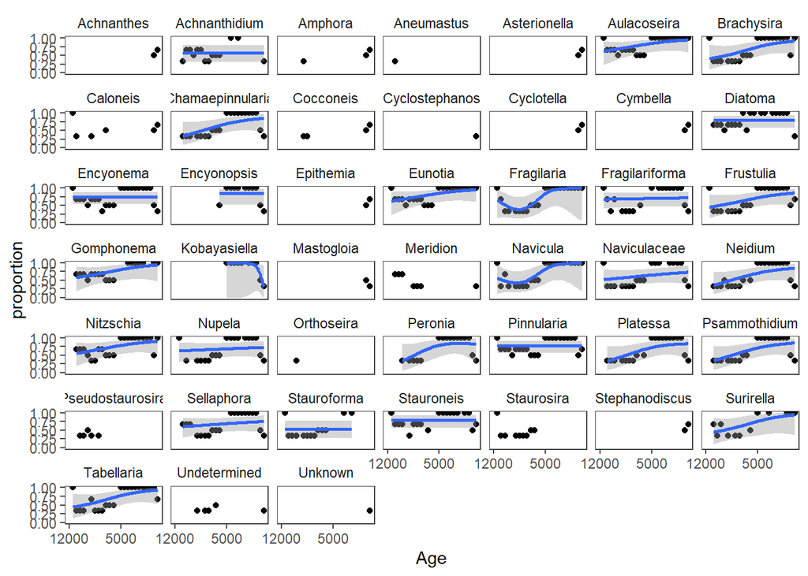

```r
ggplot(groupbyage, aes(x = age, y = proportion)) +
  geom_point() +
  geom_smooth(method = 'gam',
              method.args = list(family = 'binomial')) +
  facet_wrap(~genus) +
  coord_cartesian(xlim = c(12000, 0), ylim = c(0, 1)) +
  scale_x_reverse(breaks = c(5000, 12000)) +
  xlab("Age") +
  theme_article()
```